# Dynamic Sales Report

Coursera Learner

2026-04-01

```r
# Load required libraries
# Required packages
library(dplyr)         # For data filtering
```

```r
library(ggplot2)       # For plotting
library(readr)         # For loading CSV
library(knitr)         # For table output


# Load and parse dataset
business_data <- read_csv("business_metrics.csv")
business_data$Date <- as.Date(business_data$date)

head(business_data)
```

```
#> # A tibble: 6 × 7
#>   date       region category    sales profit transactions Date
#>   <date>     <chr>  <chr>       <dbl>  <dbl>        <dbl> <date>
#> 1 2024-01-01 North  Electronics  2380    781           10 2024-01-01
#> 2 2024-01-02 South  Clothing     4390    947           80 2024-01-02
#> 3 2024-01-03 East   Grocery      3105    120           41 2024-01-03
#> 4 2024-01-04 West   Home         4593    683           45 2024-01-04
#> 5 2024-01-05 North  Electronics  3749    295           94 2024-01-05
#> 6 2024-01-06 South  Clothing     4065    160           56 2024-01-06
```

## Activity 1: Set Up Report Parameters

### Steps:

- In the YAML header, define parameters for start_date, end_date, and department.
- Use params$ to access them in your R code chunks.
- Filter the dataset accordingly.

#### Example:

params: start_date: !r as.Date(“2024-01-01”) end_date: !r as.Date(“2024-12-31”) department: “Sales”

```r
# filtered_data <- business_data %>%
#   filter(date >= params$start_date,
#          date <= params$end_date,
#          department == params$department)
```

### Steps:

- In the YAML header, set start_date to January 1, 2024, and end_date to March 31, 2024.
- Set category to “Grocery”.
- Hint: Use `as.Date("YYYY-MM-DD")` to ensure dates are correctly formatted.

```r
 filtered_1 <- business_data %>%
    filter(date >= params$start_date,
           date <= params$end_date,
           category == params$category)
```

## Activity 2: Add Metric Selection

### Steps:

- Add a metric parameter in the YAML.
- Filter data using metric == params$metric.
- Plot or summarize this subset.

#### Example:

params: metric: “Revenue”

```r
# metric_data <- filtered_data %>%
#   filter(metric == params$metric)
```

## Try it Out #1: Allow users to toggle the metric for KPI reporting.

### Steps:

```r
metric_data <- filtered_1 %>%
  filter(params$metric > 3200)
```

# Activity 3: Add Dynamic Text and Summary

### Steps:

- Use inline R to insert selected metric, department, or date range.
- Add summary statistics such as mean and total.

#### Example:

“This report focuses on the sales metric between 2024-01-01 and 2024-03-31.”

## Try it Out #1: Prepare a narrative summary for the Marketing team.

### Steps:

- Use inline R to insert the selected region,category, metric, and date range into the narrative.
- Print the numeric values directly in the markdown section.

```r
"This report focuses on the `r params$metric` metric between `r params$start_date` and `r params$end_date`."
```

[output not shown]

# Activity 4: Add Conditional Sections

## Steps:

- Use if (params$metric == “Revenue”) inside a code chunk.
- Add plots or tables based on conditions.

#### Example:

```r
# if (params$metric == "Revenue") {
#   ggplot(metric_data, aes(x = date, y = value)) +
#     geom_line()
# }
```

### Steps:

- Ensure params$metric is set to “sales” in your YAML.
- Use if (params$metric == “sales”) to conditionally render a plot.
- Use ggplot2 to create a line plot for sales through time.

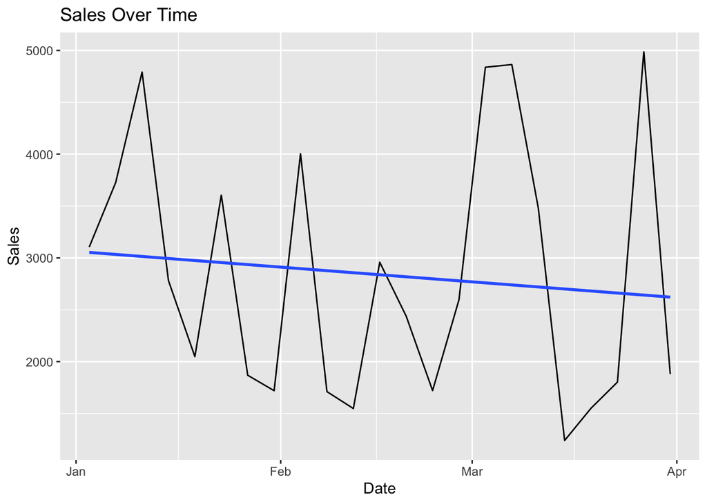

```r
if(params$metric == "sales") {
  ggplot(metric_data, aes(x = date, y = sales)) +
    geom_line() +
    geom_smooth(method = "lm", se = FALSE) +
    labs(title = "Sales Over Time", x = "Date", y = "Sales")
}
```

## Optional: Knit your report to HTML and view it. To do this you can either:

- Run `rmarkdown::render("business_metrics.Rmd")` in your R VSCode Terminal
- Run the `Knit RMD` button in VSCode

To view your final html document, right-click on `business_metrics.html` and select “Open with Live Server”. This will open up your html file in your lab’s internet browser.